# vegan PCA: Principal Components Analysis with vegans rda function

TODO: swap out irises

```r
library(compbio4all)
library(ggplot2)
```

PCA (Principal Components Analysis) is easy in R, but the standard biplot() function is a little clunky. The vegan package can do PCA using the rda() function (normally for redundancy analysis) and has some nice plotting functions. (Note that ggplot is also developing biplot tools).

# Fisher’s Irises

- 3 species
- 4 response variables

```r
data("iris")
summary(iris)
```

```
##   Sepal.Length    Sepal.Width     Petal.Length    Petal.Width
##  Min.   :4.300   Min.   :2.000   Min.   :1.000   Min.   :0.100
##  1st Qu.:5.100   1st Qu.:2.800   1st Qu.:1.600   1st Qu.:0.300
##  Median :5.800   Median :3.000   Median :4.350   Median :1.300
##  Mean   :5.843   Mean   :3.057   Mean   :3.758   Mean   :1.199
##  3rd Qu.:6.400   3rd Qu.:3.300   3rd Qu.:5.100   3rd Qu.:1.800
##  Max.   :7.900   Max.   :4.400   Max.   :6.900   Max.   :2.500
##        Species
##  setosa    :50
##  versicolor:50
##  virginica :50
##
##
##
```

# Visualize variables in 2D

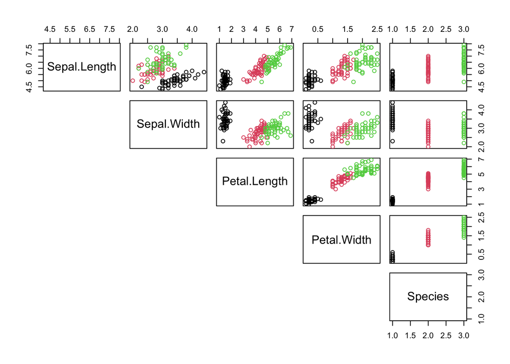

```r
pairs(iris,
      lower.panel = NULL,
      col = as.numeric(iris$Species))
```

Note: can also be done in ggplot using GGalley::ggpairs; however, not updated for most recent version of R.

# Do PCA with base R function

## Run PCA

- NOTE: there is also a similar function to princomp(), prcomp()

```r
#"[,-5]" drops that last columns
##the species code
iris.pca <- princomp(iris[,-5])
```

## Plot Biplot in base graphics

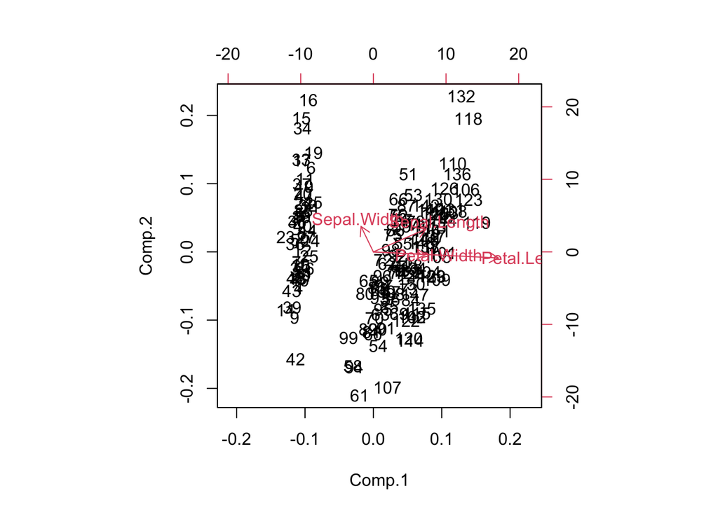

```r
biplot(iris.pca)
```

There are is also ggplot biplot code somewhere outthere on the internet.

# Do PCA with vegan::rda

- rda = redundancy analysis
- normally RDA is used for “constrained ordination” (ordination w/covariates or predictor)
- without predictors, RDA is the same as PCA
- in vegan, givig the function rda() dataframe without predictors runs a PCA very simiar to princomp

## run a vegan PCA with rda()

```r
library(vegan)
my.rda <- rda(iris[,-5])


#"[,-5]" drops that last columns
##the species code
```

## Plot the RDA

Note to get help when doing and RDA biplot, call ?biplot.rda; however, use biplot() for the actual plotting.

### Default biplot of RDA output

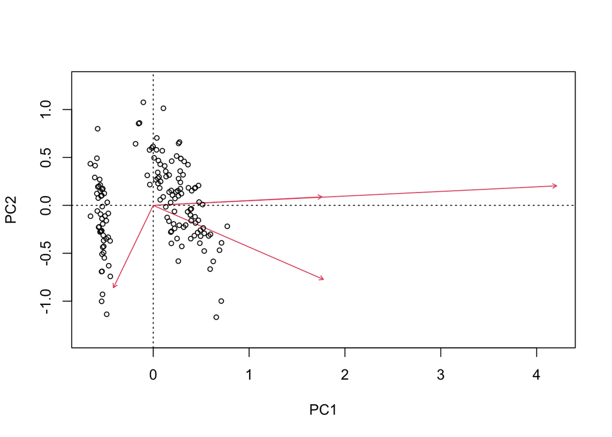

```r
biplot(my.rda)
```

Note that vegan’s scaling is different than a normal biplot.

### biplot.rda options

- vegan is package for ecological analysis and so its functions are oriented towards particular kinds of analyses
- the “display” arguement is not in the normal biplot comman used with princomp
  - “display = ‘sites’” corresonds to the rows of data; one datapoint per row
  - “display = ‘species’” corresponds to the columns of data; one line/arrow per column
- “type” is an argument also not in biplots originating from princomp
  - “type = ‘text’” plots row numbers and column names as labels
  - “type = points’” plots points

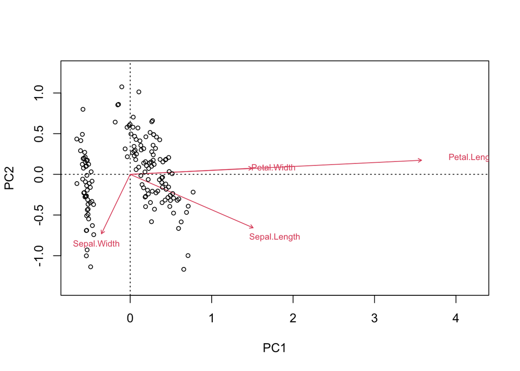

```r
biplot(my.rda,
       display = c("sites",
                   "species"),
       type = c("text",
                "points"))
```

# vegan’s ordination plotting functions

- vegan has lots of helpful functions for plotting ordinations.
  - ordihull: convex polygons around groups of points
  - ordiellipse: ellipses around centroids (SD or SE)

## Add “hulls” around each species

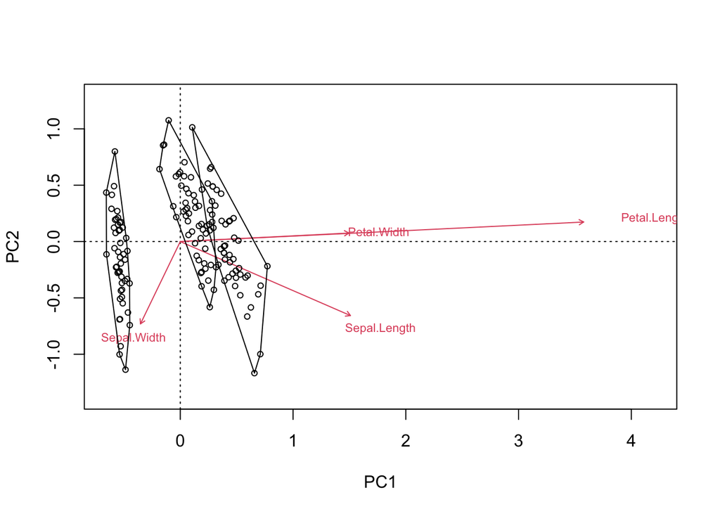

```r
#make basic plot
biplot(my.rda,
       display = c("sites",
                   "species"),
       type = c("text",
                "points"))

#Add "hulls"
ordihull(my.rda,
         group = iris$Species)
```

## Make plot pretty

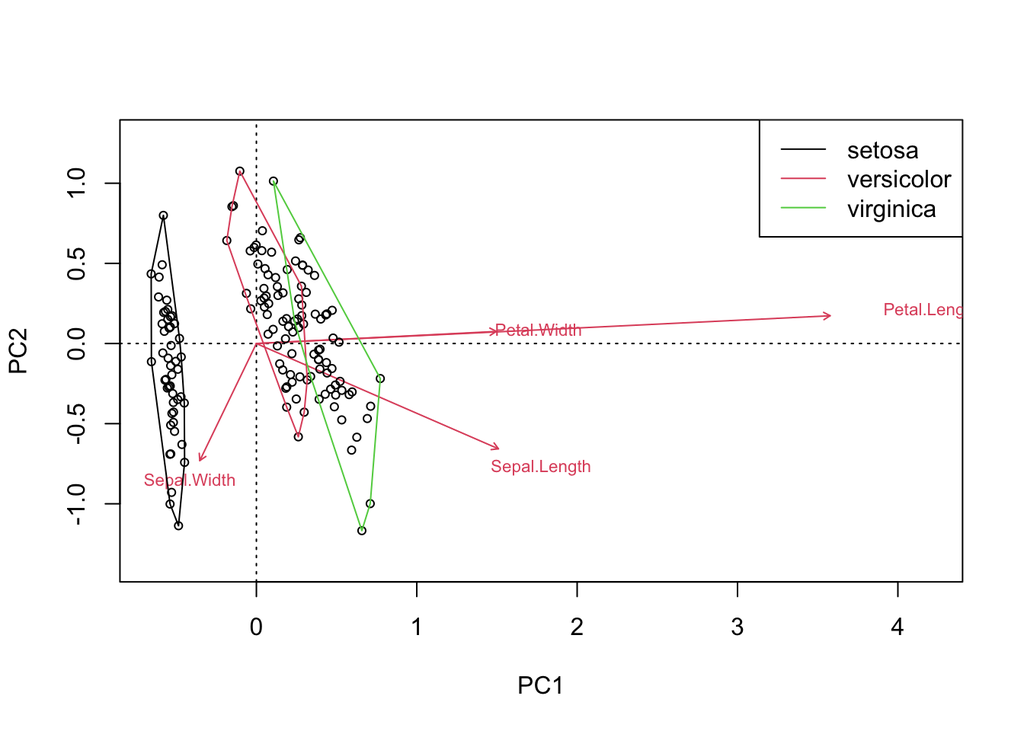

```r
#make basic plot
biplot(my.rda,
       display = c("sites",
                   "species"),
       type = c("text",
                "points"))

#get names of species
## levels() extracts fator levels
## from the column
spp.names <- levels(iris$Species)

#Add hulls
ordihull(my.rda,
         group = iris$Species,
         col = c(1,2,3))


#Add legend
legend("topright",
       col = c(1,2,3),
       lty = 1,
       legend = spp.names)
```

### with ggplot2

```r
library(vegan)

data("iris")

head(iris)
```

```
##   Sepal.Length Sepal.Width Petal.Length Petal.Width Species
## 1          5.1         3.5          1.4         0.2  setosa
## 2          4.9         3.0          1.4         0.2  setosa
## 3          4.7         3.2          1.3         0.2  setosa
## 4          4.6         3.1          1.5         0.2  setosa
## 5          5.0         3.6          1.4         0.2  setosa
## 6          5.4         3.9          1.7         0.4  setosa
```

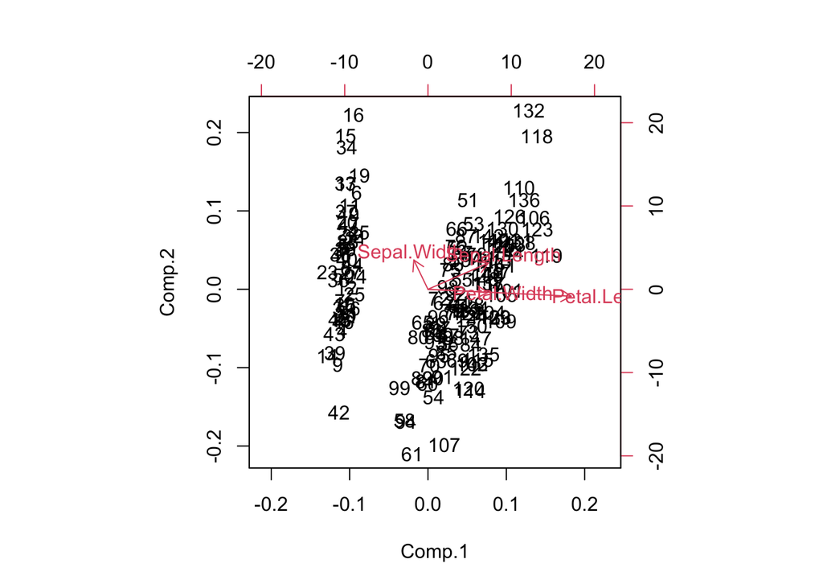

```r
biplot(princomp(iris[,-5]))
```

```r
iris.nmds <- metaMDS(iris[,-5],k = 3,
                          distance = "bray")
```

```
## *** Solution reached
```

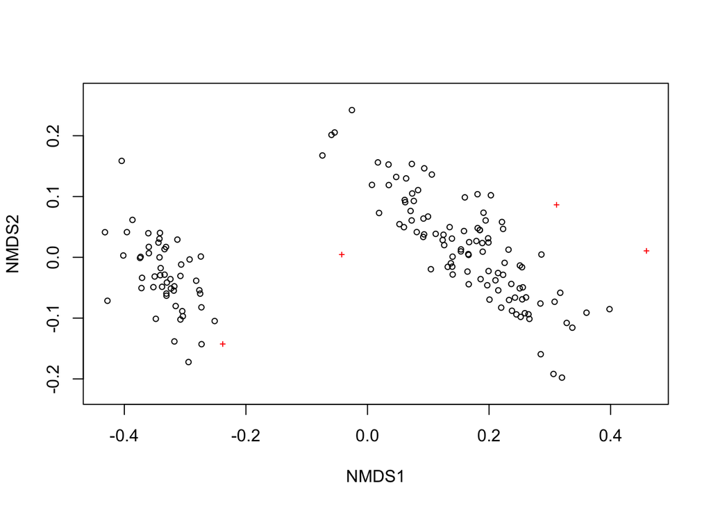

```r
ordiplot(iris.nmds)
```

```r
data.scores <- as.data.frame(scores(iris.nmds))  #Using the scores function from vegan to extract the site scores and convert to a data.frame
data.scores$site <- rownames(data.scores)  # create a column of site names, from the rownames of data.scores
data.scores$grp <- iris$Species  #  add the grp variable created earlier
head(data.scores)  #look at the data
```

```
##        NMDS1        NMDS2        NMDS3 site    grp
## 1 -0.3379648 -0.048476035  0.005369140    1 setosa
## 2 -0.3422523  0.030519177 -0.027579992    2 setosa
## 3 -0.3742574 -0.001003286 -0.050562892    3 setosa
## 4 -0.3597646  0.017176090 -0.062483998    4 setosa
## 5 -0.3522222 -0.049031824  0.009274959    5 setosa
## 6 -0.2732193 -0.082204950  0.080658809    6 setosa
```

```r
species.scores <- as.data.frame(scores(iris.nmds, "species"))  #Using the scores function from vegan to extract the species scores and convert to a data.frame
species.scores$species <- rownames(species.scores)  # create a column of species, from the rownames of species.scores
head(species.scores)  #look at the data
```

```
##                    NMDS1        NMDS2       NMDS3      species
## Sepal.Length -0.04208071  0.005109375  0.02946804 Sepal.Length
## Sepal.Width  -0.23785776 -0.142138173  0.02057073  Sepal.Width
## Petal.Length  0.31124334  0.086661497 -0.02827649 Petal.Length
## Petal.Width   0.45930685  0.011266067 -0.10931669  Petal.Width
```

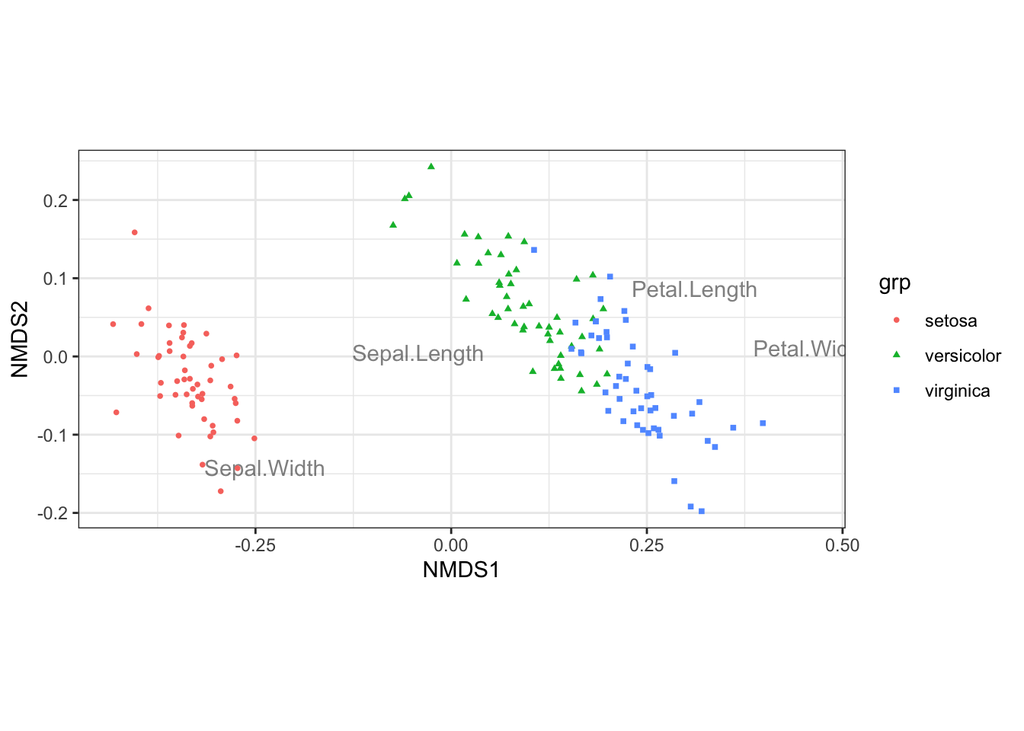

```r
ggplot() +
  geom_text(data=species.scores,
            aes(x=NMDS1,y=NMDS2,
                label=species),alpha=0.5) +  # add the species labels
  geom_point(data=data.scores,
             aes(x=NMDS1,y=NMDS2,shape=grp,colour=grp),size=1) + # add the point markers
  #geom_text(data=data.scores,aes(x=NMDS1,y=NMDS2,label=site),size=6,vjust=0) +  # add the site labels
  #scale_colour_manual(values=c("A" = "red", "B" = "blue")) +
  coord_equal() +
  theme_bw()
```